# Sales Spotlight: Insights on Product and Location-Based Performance

Onifade Monsuru

2024-07-04

## Introduction

In today’s competitive market, understanding sales trends and customer behavior is crucial for businesses to make informed decisions and drive growth. This project aims to analyze sales data to uncover insights into product performance, sales patterns, and customer purchasing habits. By exploring these areas,the goal is to identify opportunities for improvement and optimization.

## Executive Summary

By acting on these insights, we can optimize our product offerings, sales strategies, and customer engagement to drive business growth and revenue.

## Data Overview

```
## Rows: 185,950
## Columns: 11
## $ X                <int> 0, 1, 2, 3, 4, 5, 6, 7, 8, 9, 10, 11, 12, 13, 14, 15,…
## $ Order.ID         <int> 295665, 295666, 295667, 295668, 295669, 295670, 29567…
## $ Product          <chr> "Macbook Pro Laptop", "LG Washing Machine", "USB-C Ch…
## $ Quantity.Ordered <int> 1, 1, 1, 1, 1, 1, 1, 2, 1, 4, 2, 1, 2, 2, 1, 1, 1, 1,…
## $ Price.Each       <dbl> 1700.00, 600.00, 11.95, 149.99, 11.95, 3.84, 11.95, 1…
## $ Order.Date       <chr> "2019-12-30 00:01:00", "2019-12-29 07:03:00", "2019-1…
## $ Purchase.Address <chr> "136 Church St, New York City, NY 10001", "562 2nd St…
## $ Month            <int> 12, 12, 12, 12, 12, 12, 12, 12, 12, 12, 12, 12, 12, 1…
## $ Sales            <dbl> 1700.00, 600.00, 11.95, 149.99, 11.95, 3.84, 11.95, 2…
## $ City             <chr> " New York City", " New York City", " New York City",…
## $ Hour             <int> 0, 7, 18, 15, 12, 22, 15, 9, 23, 11, 13, 17, 19, 9, 9…
```

### Unique OrderID

This statistic shows the total number of unique orders processed, which is **178,437** out of a total of **185,950** records. This indicates that approximately **96%** of the records represent unique orders **(178,437 / 185,950)**.

## Quantity Ordered Statistics

```
##       Mean Median        SD Min Max
## 1 1.124383      1 0.4427926   1   9
```

**Interpretation**: The minimum quantity ordered is 1, and the maximum is 9.

### Price Statistics

```
##       Mean       SD  Min  Max
## 1 184.3997 332.7313 2.99 1700
```

**Interpretation**: The average price per item is **$184.40**, with a standard deviation of **$332.73**, indicating significant variation in prices.The minimum price is **$2.99** , and the maximum price is **$1,700**.

### Sales Statistics

```
##       Mean Median       SD  Min  Max
## 1 185.4909  14.95 332.9198 2.99 3400
```

**Interpretation**: The average sales amount is **$185.49**, with a median of **$14.95**. The standard deviation is **$332.92**, indicating significant variation in sales amounts. The minimum sales amount is **$2.99**, and the maximum is **$3,400**.

# Product Sales Performance

### 1. Which product has the highest total Quantity Sold?

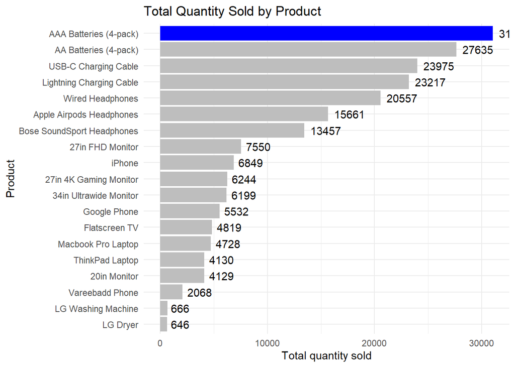

**Interpretation**: **AAA Batteries (4-pack)** has the highest total quantity sold with **31,017**units.

### 2. Which product has the highest revenue share?

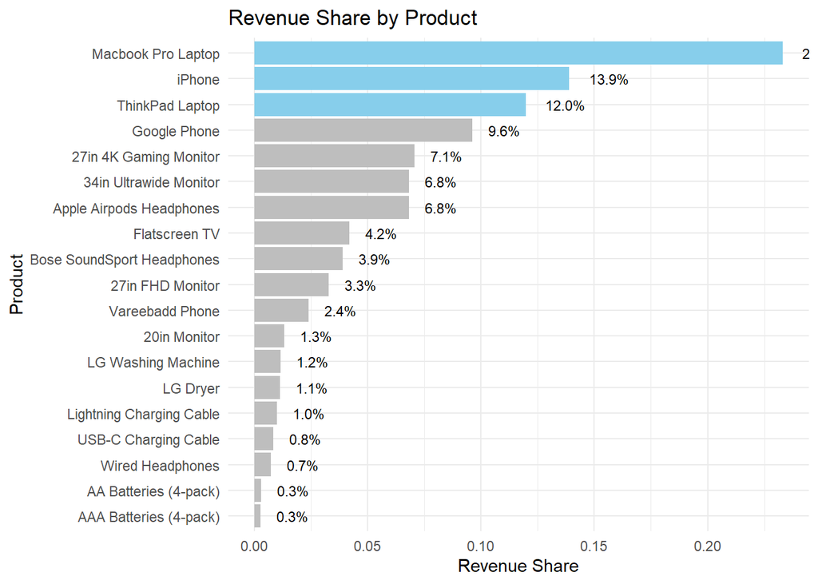

**Interpretation**: **Macbook Pro Laptop** has the highest total sales with **$8,037,600**.

# Sales by Location

### Which cities have the highest and lowest total sales?

```
## [1] " San Francisco" " Los Angeles"   " New York City" " Boston"
## [5] " Atlanta"       " Dallas"        " Seattle"       " Portland"
## [9] " Austin"
```

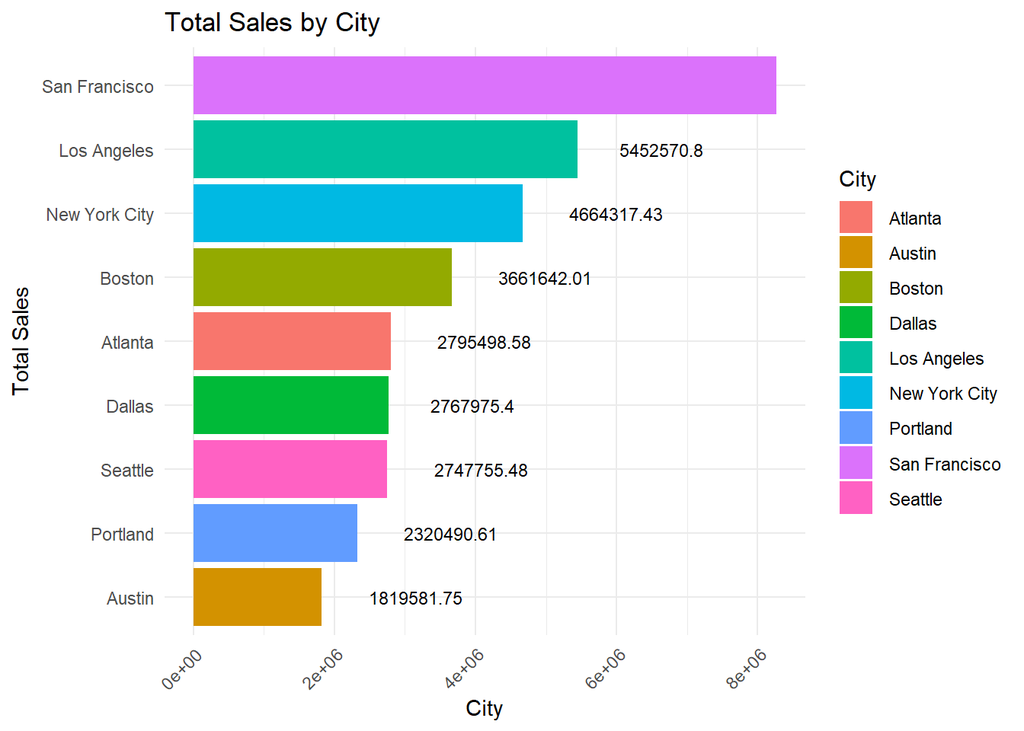

**Interpretation**: **San Francisco**, with total sales of **$8,262,204** while **Austin** has the least with total sales of **$1,819582**.

This indicates that **San Francisco** has generated the most sales revenue among all cities, surpassing other major cities like **Los Angeles and New York City**. This insight could be useful for business decisions such as resource allocation, marketing strategies, and expansion plans.

# Sales Trends and Patterns

### Which month has the highest total sales?

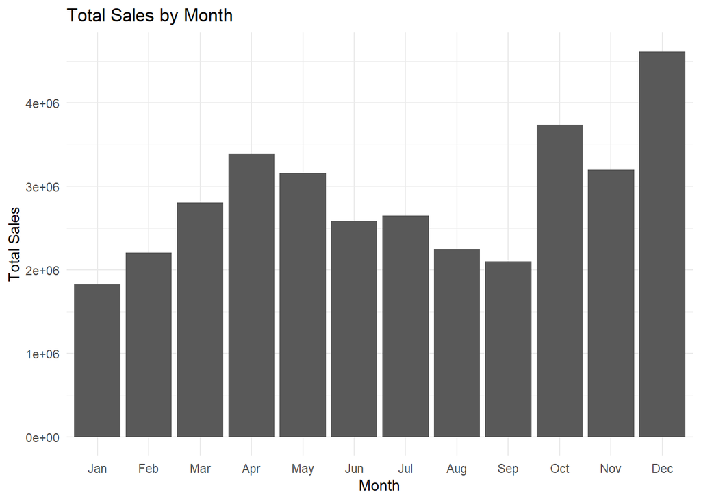

**Interpretation**: Sales peaked in **December** with a revenue of **$4,613,443** .

### Is there a seasonal pattern in sales?

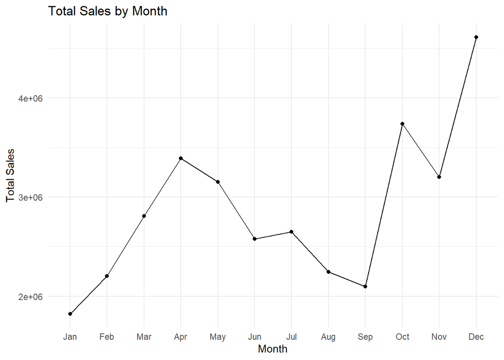

**Interpretation**: Sales Trend **rose** from **January to April** then **dipped** from **April to September** before **rallying** from **September to December**.

### What is the peak sales hour of the day?

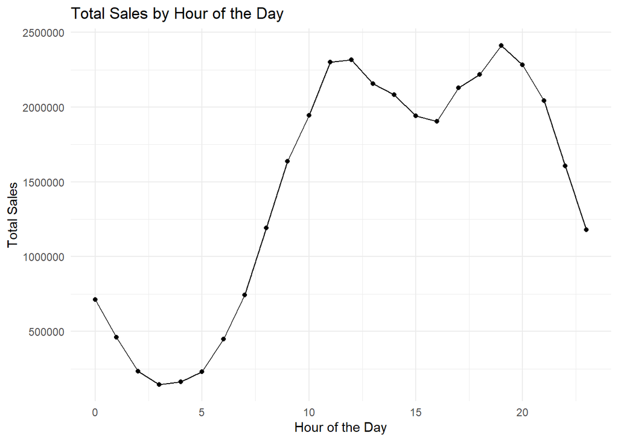

**Interpretation**: **Most sales activities happened at 7:00 p.m** while down time often occur at 3:00 A.M.